# Guatemala Performance Indicators

Francisco Rios Casas

November 11, 2019

## 1. Introduction

| File | Start of Reporting Period | End of Reporting Period |
| --- | --- | --- |
| GTM-T-MSPAS_Progress Report_30Jun2019_Final Review LFA.xlsx | 2019-01-01 | 2019-06-30 |
| GTM-H-INCAP_Progress Report_30Jun2019_v10_30082019_RevALF english version.xlsx | 2018-10-01 | 2019-06-30 |

**There are two grants reporting for the most recent time period S1 2019.**

## 2. Grant Results based on most recent PUDRs

The “Achievement Ratio” is calculated in the PUDR to understand how close to the original target the Outcome Indicator result is. A value of 1.0 or greater means that the Indicator’s goal has been met or exceeded.

### TB Grant

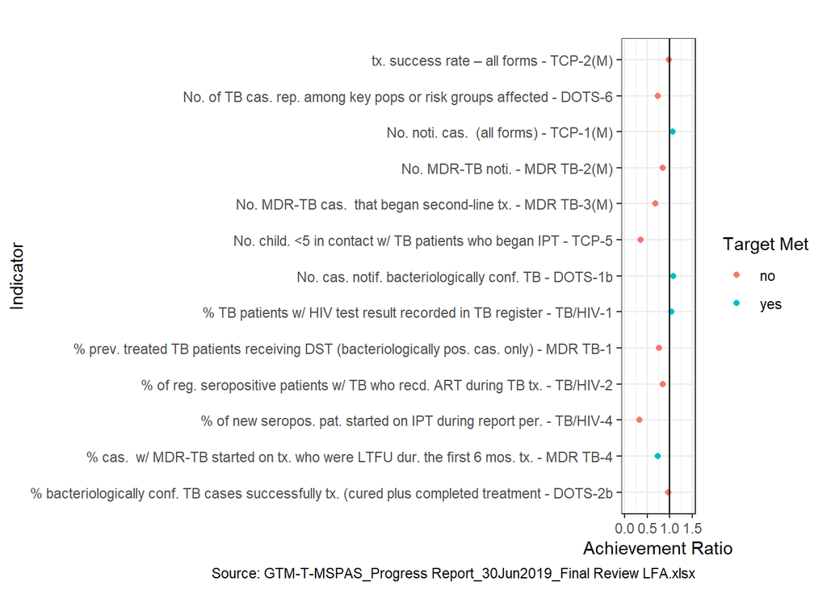

### HIV Grants

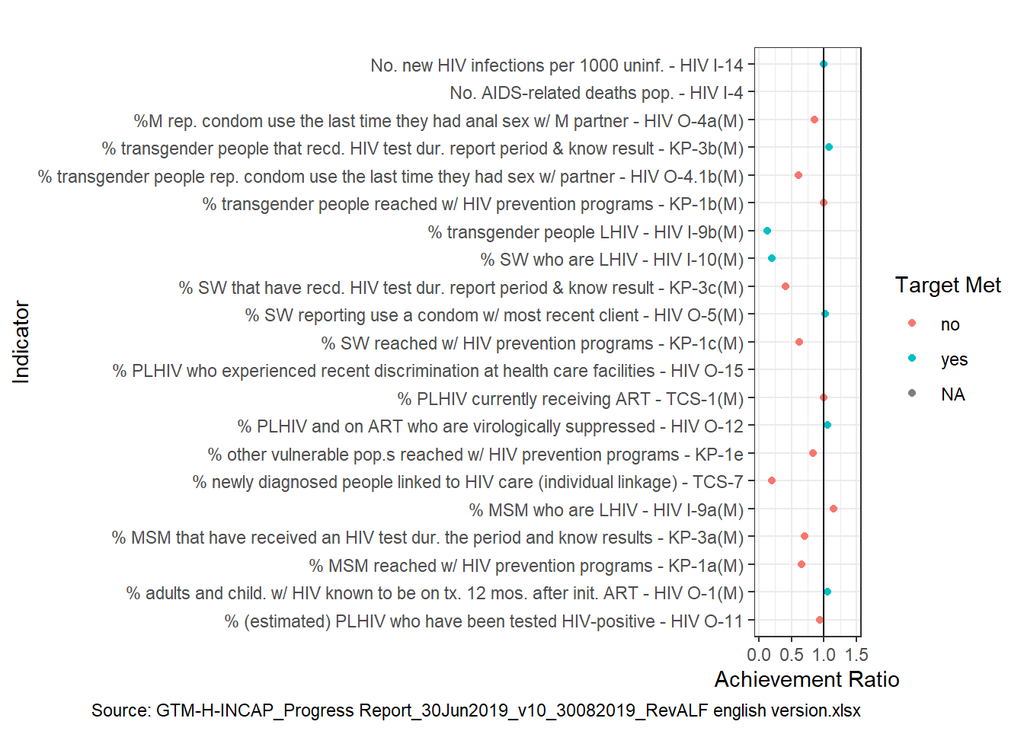

**The indicators furthest from their targets relate to linkage to care for people newly diagnosed with HIV and HIV testing and prevention programs for Sex workers and MSM.**

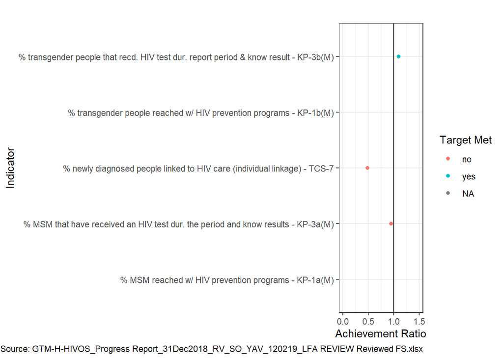

**Results available for S2 2018.**

### Malaria Grant

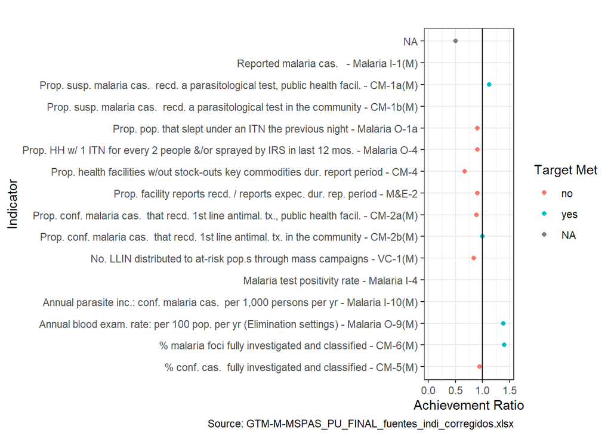

**Majority of indicators are close even if they are not meeting their targets. Stock-out of key commodities is the indicator that is furthest from target.**

**Results available for S2 2018.**